# SF Vignette

Glen Pridham 2023 Rutengroup

Tutorial on using sf.R. SF: stochastic finite model.

Purpose: demonstrate a simple analysis pipeline.

```r
outputDir = ""  #enter the file location for the SF (github) files here
source(sprintf("%s/sf.R",outputDir))
```

We start with some data. Data typically: (1) are stored in matrices (e.g. long format), and (2) have missing values / censorship.

We start with a long format matrix (i.e. each row is a particular individual measured at a particular age).

# Load data

```r
long  = read.csv(sprintf("%s/test_censored_data_long.csv",outputDir))
```

The data are complete but there are deaths such that not each individual has the same number of timepoints.

```r
head(long)
```

|  | id | sex | baseline_age | death_age | status | age | y01 | y02 | y03 | y04 | y05 |
| --- | --- | --- | --- | --- | --- | --- | --- | --- | --- | --- | --- |
| 1 | 1 | 1 | 62.05999 | 100.70577 | 1 | 62.05999 | -8.2918403 | -2.033885 | 10.165729 | -3.752700 | 5.811182 |
| 2 | 2 | 0 | 56.38943 | 96.65369 | 1 | 56.38943 | 3.5820419 | -10.057003 | 23.853860 | 7.750511 | -1.227232 |
| 3 | 3 | 0 | 67.58163 | 77.92315 | 1 | 67.58163 | -0.9201186 | 11.856476 | 21.459191 | 20.647473 | 10.758190 |
| 4 | 4 | 0 | 52.73295 | 79.27273 | 1 | 52.73295 | 18.8482228 | -22.058919 | -23.195295 | -21.641786 | -9.838101 |
| 5 | 5 | 0 | 46.31719 | 82.98680 | 1 | 46.31719 | -2.7784503 | 9.403959 | -4.952790 | 13.062962 | -24.657561 |
| 6 | 6 | 0 | 64.32818 | 98.31434 | 1 | 64.32818 | 14.0891707 | -17.125583 | 3.198258 | 4.697923 | 16.287824 |

It is instructive to include missing entries. Here we generate missingness completely at random in the predictor variables, y01-y05. We randomly drop 25% of values.

```r
longMiss = long
vars = sprintf("y%02d",1:5)
for (j in 1:length(vars)) longMiss[sample(1:nrow(longMiss),nrow(longMiss)%/%4),vars[j]] = NA
print(sprintf("Number of NAs before: %d (%.0f%%)",sum(is.na(long[,vars])),100*mean(is.na(long[,vars]))))
```

```
[1] "Number of NAs before: 0 (0%)"
```

```r
print(sprintf("Number of NAs after: %d (%.0f%%)",sum(is.na(longMiss[,vars])),100*mean(is.na(longMiss[,vars]))))
```

```
[1] "Number of NAs after: 22255 (25%)"
```

# Reshape data

The model is designed to handle regularly sampled data and hence is programmed to take 3d arrays as input (individual x variable x time).

Our model takes as input: -the longitudinal predictors to be fitting, y (3d array) -covariates, x (3d array) -time step size from t_n to t_n+1, dt (2d matrix) - if unknown defaults to dt=1 -(optionally) survival information to avoid imputing dead individuals (if desired)

We can reshape the long-format dataframe using Reshape.

We will also generate survival information.

```r
#this will run but obscures details
#re = Reshape(data=longMiss,
#             ycols=sprintf("y%02d",1:5), #these are the primary variables we want to build a network for
#             xcols=c("age","sex") #these are the covariates which could affect equilibrium positions
#             )

#includes everything under the hood
re = Reshape(data=longMiss,
             ycols=sprintf("y%02d",1:5), #these are the primary variables we want to build a network for
             xcols=c("age","sex"), #these are the covariates which could affect equilibrium positions
             idCol="id", #this is the name of the column with a unique patient identifier
             ageCol="age", #age column - used for dt
             doSurv=T, #specify that you want to also make a survival object (using Surv)
             startCol="baseline_age", #age of entry into study - used for survival
             stopCol="death_age", #age of exit from study - used for survival
             statusCol="status", #reason for exiting study (0: censored, 1: died)
             stationary=c("sex") #variables in x that will not change during the course of the study
             )
```

```
[1] "N: 1000"
[1] "timepoints: 20"
[1] "random spot checks (ages should be increasing):"
     t01      t02      t03      t04      t05      t06      t07      t08      t09      t10      t11      t12      t13      t14
72.48864 73.40565 74.41878 75.49688 76.43773 77.33980 78.30202 79.22584 80.36448       NA       NA       NA       NA       NA
     t15      t16      t17      t18      t19      t20
      NA       NA       NA       NA       NA       NA
     t01      t02      t03      t04      t05      t06      t07      t08      t09      t10      t11      t12      t13      t14
75.75728 76.74643 77.65757 78.78460 79.94421 80.96835 82.12664 83.18965       NA       NA       NA       NA       NA       NA
     t15      t16      t17      t18      t19      t20
      NA       NA       NA       NA       NA       NA
     t01      t02      t03      t04      t05      t06      t07      t08      t09      t10      t11      t12      t13      t14
60.49067 61.63211 62.53674 63.56730 64.56228 65.64532 66.61497 67.60357 68.51156 69.45377 70.46238 71.32148 72.28719 73.31940
     t15      t16      t17      t18      t19      t20
74.26549 75.23205 76.17839 77.07178 78.20422 79.19411
[1] "sanity check on imputed ages, should be 0:"
[1] 0
```

Aside: by default preprocess=T and Reshape will include both y, a 3d array of predictors to fit with, and ypp, a preprocessed version of y. The preprocessed version centers by the baseline sex-specific mean and scales by the pooled standard deviation. The effects of age are then to change values away from mean 0, unit variance.

```r
print(names(re))
```

```
[1] "y"   "x"   "dt"  "s"   "ypp" "mu"  "sd"
```

Reshape produces all of the input needed to fit a model. The data are stored in arrays and, in the case of s, a Surv type object (which behaves mostly like a matrix).

```r
print(names(re))
```

```
[1] "y"   "x"   "dt"  "s"   "ypp" "mu"  "sd"
```

```r
for (i in 1:length(re)) print(dim(re[[i]]))
```

```
[1] 1000    5   20
[1] 1000    2   20
[1] 1000   19
[1] 1000    3
[1] 1000    5   20
[1] 2 5
NULL
```

Notice that y is of dimensions 1000 x 5 x 20, that is: 1000 individuals, 5 variables and 20 timepoints. What about individuals whom were measured less than 20 times? New, empty, entries are instantiated for those individuals using a piecewise linear model.

```r
print(subset(longMiss,id==3))
```

|  | id | sex | baseline_age | death_age | status | age | y01 | y02 | y03 | y04 | y05 |
| --- | --- | --- | --- | --- | --- | --- | --- | --- | --- | --- | --- |
| 3 | 3 | 0 | 67.58163 | 77.92315 | 1 | 67.58163 | -0.9201186 | 11.8564761 | NA | NA | 10.7581902 |
| 1003 | 3 | 0 | 67.58163 | 77.92315 | 1 | 68.35385 | 2.6570237 | 10.3977324 | 7.8818752 | 6.9821336 | NA |
| 1996 | 3 | 0 | 67.58163 | 77.92315 | 1 | 69.35686 | 4.6767985 | 7.0693573 | 4.7863663 | NA | 7.1006297 |
| 2980 | 3 | 0 | 67.58163 | 77.92315 | 1 | 70.46277 | NA | 2.2626433 | NA | 2.0147479 | 4.2031350 |
| 3955 | 3 | 0 | 67.58163 | 77.92315 | 1 | 71.40759 | 2.2929640 | 1.7511260 | -1.1580020 | 2.0798250 | NA |
| 4926 | 3 | 0 | 67.58163 | 77.92315 | 1 | 72.46066 | 1.7317880 | NA | -0.4805364 | 1.5488150 | -0.1735495 |
| 5886 | 3 | 0 | 67.58163 | 77.92315 | 1 | 73.48269 | NA | 1.6300400 | NA | -2.2397690 | 1.3595780 |
| 6835 | 3 | 0 | 67.58163 | 77.92315 | 1 | 74.39992 | 1.6477620 | -2.0302900 | -0.6678670 | NA | -0.7490266 |
| 7777 | 3 | 0 | 67.58163 | 77.92315 | 1 | 75.29836 | NA | NA | -1.1656890 | 0.5820154 | -4.1107780 |
| 8707 | 3 | 0 | 67.58163 | 77.92315 | 1 | 76.18100 | 2.7253950 | 1.0383320 | 0.9386092 | -3.9543920 | -1.2862450 |

[output cut: 1 more lines]

New ages are introduced for when id = 3 WOULD have been measured

```r
print(re[["x"]][3,"age",])
```

```
      t01       t02       t03       t04       t05       t06       t07       t08       t09       t10       t11       t12
 67.58163  68.35385  69.35686  70.46277  71.40759  72.46066  73.48269  74.39992  75.29836  76.18100  77.15772  80.47678
      t13       t14       t15       t16       t17       t18       t19       t20
 83.79583  87.11489  90.43394  93.75300  97.07206 100.39111 103.71017 107.02922
```

Any stationary variables were carried forward e.g. sex,

```r
print(re[["x"]][3,"sex",])
```

```
t01 t02 t03 t04 t05 t06 t07 t08 t09 t10 t11 t12 t13 t14 t15 t16 t17 t18 t19 t20
  0   0   0   0   0   0   0   0   0   0   0   0   0   0   0   0   0   0   0   0
```

But there are no values for any of the key predictor variables past the last measurement date,

```r
print(re[["y"]][3,1,])
```

```
       t01        t02        t03        t04        t05        t06        t07        t08        t09        t10        t11
-0.9201186  2.6570237  4.6767985         NA  2.2929640  1.7317880         NA  1.6477620         NA  2.7253950  0.4523013
       t12        t13        t14        t15        t16        t17        t18        t19        t20
        NA         NA         NA         NA         NA         NA         NA         NA         NA
```

Recall that we added random missingness as well, hence some intermediate measurements are also missing.

When we fit the model we will have the option (default) of imputing all of these missing values.

# Fitting a basic model

If we use the default settings, we can quickly fit a model.

```r
sf = FitSF(y=re[["y"]],x=re[["x"]],dt=re[["dt"]])
```

```
[1] "Imputing age in column age"
[1] "Age imputation correct?"
[1] TRUE
[1] "Iterations selected: 5.0"
[1] "Noise precision matrix has been supplied..."
[1] "NAs to replace: 33225, total NAs: 33225 (diff: 0)"
[1] "NAs to replace: 33225, NAs replaced by initial imputation: 33045 (imputed: 99%)"
[1] "initial imputation options:"
list()
[1] "NAs after iterating:"
[1] 171
```

We now have a set of parameters including an interaction network and equilibrium positions.

We may want to specify some additional constraints, for example perhaps we don’t want to impute the censored and dead individuals.

There are two imputation rounds: (1) an initial imputation (imputeFirst) that uses a basic algorithm to impute as many values as possible, and (2) an iterative imputation at each iteration (imputeMean) that imputes the model mean.

NOTE: you do not have to impute, the estimators will work even if some data are missing.

```r
#more revealing
sf = FitSF(y=re[["y"]], #main variables
           x=re[["x"]], #covariates
           dt=re[["dt"]], #step size
           s=re[["s"]], #survival, used for imputation constraints
           age = re[["x"]][,"age",], #used for imputation contraints
           imputeFirst=T, #do you want to impute once before doing any preprocessing?
           imputeFirstFunOptions = list(method="carryback"), #initial imputation will carry forward previous values then carry back future  values to replace any still missing
           imputeMean=T, #iteratively impute the model mean
           imputeDead=F, #do you want to impute individuals after they've died? #we have found this can reduce bias, but it can also increase bias if you have many timepoints
           imputeCensored=F, #same with previous
           fixedQ = NA #noise parameter #set to NA to fit iteratively
           )
```

```
[1] "Not imputing dead..."
[1] "Not imputing censored..."
[1] "Imputing age in column age"
[1] "Age imputation correct?"
[1] TRUE
[1] "Iterations selected: 5.0"
[1] "NAs to replace: 22265, total NAs: 33225 (diff: 10960)"
[1] "NAs to replace: 22265, NAs replaced by initial imputation: 22254 (imputed: 100%)"
[1] "initial imputation options:"
$method
[1] "carryback"

[1] "NAs after iterating:"
[1] 10962
```

The primary parameters of the model are an interaction network and equilibrium positions for each variable.

```r
print("Network:")
```

```
[1] "Network:"
```

```r
print(round(sf$W,3))
```

```
       y01    y02    y03    y04    y05
y01 -0.321 -0.024  0.053  0.040  0.002
y02 -0.031 -0.296  0.064  0.044 -0.059
y03  0.065  0.083 -0.548 -0.086 -0.013
y04  0.046  0.071 -0.102 -0.643  0.105
y05  0.005 -0.077 -0.009  0.089 -0.276
```

```r
print("Equilibrium positions:")
```

```
[1] "Equilibrium positions:"
```

```r
print(round(sf$lambda[,"mu0"],3))
```

```
   y01    y02    y03    y04    y05
-0.535  0.073 -2.048  0.102 -0.685
```

Equilibrium positions can depend on covariates

```r
print("Equilibrium position covariates:")
```

```
[1] "Equilibrium position covariates:"
```

```r
print(round(sf$lambda[,-1],3))
```

```
       age    sex
y01  0.006 -0.334
y02  0.002 -0.253
y03  0.015 -0.142
y04 -0.001 -0.525
y05  0.005  0.034
```

Finally, we have our estimate for the noise. Q is the inverse covariance at each timepoint,

```r
print("Q, inverse covariance:")
```

```
[1] "Q, inverse covariance:"
```

```r
print(round(sf$Q,3))
```

```
       y01    y02    y03    y04    y05
y01  0.455  0.020 -0.015 -0.016 -0.004
y02  0.020  0.428 -0.017 -0.012 -0.006
y03 -0.015 -0.017  0.387  0.021  0.008
y04 -0.016 -0.012  0.021  0.362 -0.023
y05 -0.004 -0.006  0.008 -0.023  0.466
```

Note that Q will be biased if you have imputed values.

Speaking of imputed values, they are stored in yimp. Observe the impute values compared to the observed for an individual,

```r
plot(re[["x"]][1,"age",],re[["y"]][1,1,],xlab="Age",ylab=colnames(re[["y"]])[1])
points(sf[["x"]][1,"age",],sf[["yimp"]][1,1,],pch=3,col=3)
```

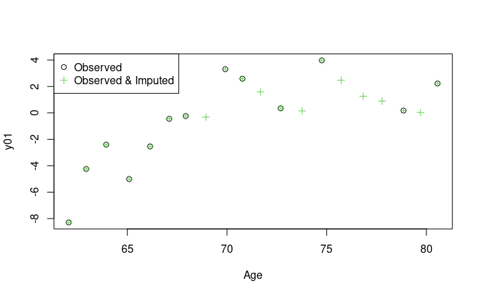

```r
legend("topleft",c("Observed","Observed & Imputed"),col=c(1,3),pch=c(1,3))
```

The imputed values are the model mean for that individual and depend on the previous timepoint as well as any variables measured at the current timepoint.

# Bootstrapping - to get error estimates

BootSF simply calls FitSF repeatedly. The parameters from each iteration are then pooled as the mean with error estimated by the standard deviation. You can optionally also use quantiles (but it is slow).

BootSF will also perform out-of-sample error estimates useful for model selection. Note that typically the test error is biased high and the train error is biased low, so the 632 error is a good tradeoff: 632 error = 0.368 x train error + 0.632 x test error.

All options must be supplied as a list, named options.

BootSF can use multiple cores for parallel computing with the parallel package.

Repeating the previous fit with bootstrap is achieved as follows:

```r
options = list(imputeFirst=T, #do you want to impute once before doing any preprocessing?
           imputeFirstFunOptions = list(method="carryback"), #initial imputation will carry forward previous values then carry back future  values to replace any still missing
           imputeMean=T, #iteratively impute the model mean
           imputeDead=F, #do you want to impute individuals after they've died? #we have found this can reduce bias, but it can also increase bias if you have many timepoints
           imputeCensored=F, #same with previous
           fixedQ = NA #noise parameter #set to NA to fit iteratively
           )

sfbs = BootSF(y=re[["y"]], #main variables
           x=re[["x"]], #covariates
           dt=re[["dt"]], #step size
           s=re[["s"]], #survival, used for imputation constraints
           age = re[["x"]][,"age",], #used for imputation contraints
           options=options,
           mc.cores=1, #number of cores to use: more = faster = more memory usage
           nboot=10, #number of bootstrap iterations
           quantiles=NULL, #for robust pooling of bootstraps
           keepImp=T #this will keep the imputed values, giving us a distribution of values for each imputation
           )
```

```
[1] "Not imputing dead..."
[1] "Not imputing censored..."
[1] "Imputing age in column age"
[1] "Age imputation correct?"
[1] TRUE
[1] "Iterations selected: 5.0"
[1] "NAs to replace: 22722, total NAs: 32362 (diff: 9640)"
[1] "NAs to replace: 22722, NAs replaced by initial imputation: 22710 (imputed: 100%)"
[1] "initial imputation options:"
$method
[1] "carryback"

[1] "NAs after iterating:"
[1] 9643
[1] "Not imputing dead..."
```

[output cut: 126 more lines]

```
[1] "quants"
[1] "imputed values..."
```

The mean/sd are stored in meansd, which provides lists. The first entry is the mean and the second is the standard deviation (= standard error estimate).

For example, the network is

```r
print("Network:")
```

```
[1] "Network:"
```

```r
print(round(sfbs[["meansd"]][["W"]][[1]],3))
```

```
       y01    y02    y03    y04    y05
y01 -0.323 -0.023  0.053  0.040  0.002
y02 -0.028 -0.295  0.061  0.043 -0.059
y03  0.065  0.084 -0.551 -0.087 -0.014
y04  0.050  0.072 -0.106 -0.647  0.107
y05  0.005 -0.076 -0.011  0.090 -0.276
```

With error estimates

```r
print("Network errors:")
```

```
[1] "Network errors:"
```

```r
print(round(sfbs[["meansd"]][["W"]][[2]],3))
```

```
      y01   y02   y03   y04   y05
y01 0.004 0.003 0.006 0.004 0.003
y02 0.006 0.003 0.005 0.007 0.003
y03 0.005 0.006 0.010 0.009 0.003
y04 0.006 0.007 0.009 0.013 0.003
y05 0.005 0.003 0.006 0.007 0.003
```

For keepImp = T the imputed values are stored. This provides a distribution of values for each imputation.

The errorbars are quite small, so I’ll scale them up to confidence intervals.

```r
#errorScale = 1 #68.2% CI (standard error)
errorScale = qnorm(.975) #95% CI
#errorScale = qnorm(.9995) #99.9% CI

plot(re[["x"]][1,"age",],re[["y"]][1,1,],xlab="Age",ylab=colnames(re[["y"]])[1])
#points(sfbs[["xgt"]][1,"age",],sfbs[["yimp"]][1,1,],pch=3,col=3)
arrows(sfbs[["xgt"]][1,"age",], sfbs[["yimp"]][1,1,]-errorScale*sfbs[["yimpsd"]][1,1,], sfbs[["xgt"]][1,"age",], sfbs[["yimp"]][1,1,]+errorScale*sfbs[["yimpsd"]][1,1,], length=0, angle=90,code=3,col=3) #add errorbars
```

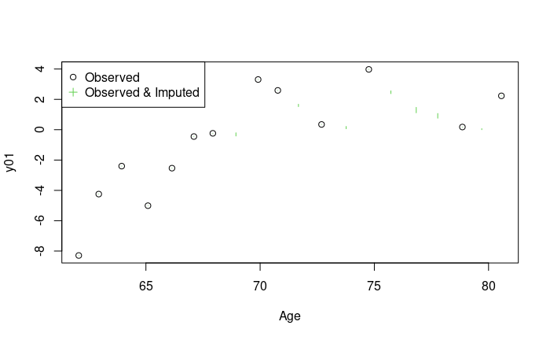

```r
legend("topleft",c("Observed","Observed & Imputed"),col=c(1,3),pch=c(1,3))
```